```python
import pandas as pd
import numpy as np
import tweepy
import matplotlib.pyplot as plt
%matplotlib inline
import json
import requests
import os
import seaborn as sns
import re


from functools import reduce
from datetime import datetime
```

# Gathering Data

```python
twitter_archive = pd.read_csv('twitter_archive_enhanced.csv')
```

```python
image_predictions_url = 'https://d17h27t6h515a5.cloudfront.net/topher/2017/August/599fd2ad_image-predictions/image-predictions.tsv'
response = requests.get(image_predictions_url)
with open(os.path.join('image_predictions.tsv'), mode = 'wb') as file:
    file.write(response.content)
```

```python
image_predictions = pd.read_csv('image_predictions.tsv',sep = '\t')
```

```python
consumer_key = 'ztP4yVNJxDctzFe2In3TtmdBw'
consumer_secret = 'i1XCndSJ3OTKVEy1QCTIB4jIebzz5PSCrW02xU0H64E0YADmTn'
access_token = '765937421762650112-8rsTDC5Q5R2fMAeiur8JF46Dkon8Lh1'
access_secret = 'NIVJHNIYuH4oj47gAELzyrc0yA3ddDfkd9afAqsNQs1sV'

auth = tweepy.OAuthHandler(consumer_key, consumer_secret)
auth.set_access_token(access_token, access_secret)


api = tweepy.API(auth, parser=tweepy.parsers.JSONParser())
```

[Ref 1 (api = tweepy.API(auth) won't work)](https://github.com/tweepy/tweepy/issues/1102)

```python
Tweet_id = list(twitter_archive.tweet_id)

tweet_statuss = []
tweet_statuss_id= []
id_errors = []
for ids in Tweet_id:
    try:
        statuss = api.get_status(ids,
                              tweet_mode='extended',
                              wait_on_rate_limit = True,
                              wait_on_rate_limit_notify = True)
        tweet_statuss.append(statuss)
        tweet_statuss_id.append(ids)
    except:
        id_errors.append(ids)
        print(ids)
```

```
888202515573088257
873697596434513921
872668790621863937
872261713294495745
869988702071779329
866816280283807744
861769973181624320
856602993587888130
851953902622658560
845459076796616705
844704788403113984
842892208864923648
837366284874571778
837012587749474308
Rate limit reached. Sleeping for: 291
829374341691346946
827228250799742977
812747805718642688
802247111496568832
779123168116150273
775096608509886464
771004394259247104
770743923962707968
759566828574212096
754011816964026368
Rate limit reached. Sleeping for: 736
680055455951884288
Rate limit reached. Sleeping for: 736
```

```python
with open('tweet_json.txt', mode = 'w') as outfile:
    json.dump(tweet_statuss, outfile)
```

```python
# Load the Twitter API data
tweet_json = pd.read_json('tweet_json.txt')
tweet_json['tweet_id'] = tweet_statuss_id
```

## Assessing

```python
twitter_archive.sample(5)
```

|  | tweet_id | in_reply_to_status_id | in_reply_to_user_id | timestamp | source | text | retweeted_status_id | retweeted_status_user_id | retweeted_status_timestamp | expanded_urls | rating_numerator | rating_denominator | name | doggo | floofer | pupper | puppo |
| --- | --- | --- | --- | --- | --- | --- | --- | --- | --- | --- | --- | --- | --- | --- | --- | --- | --- |
| 2149 | 669684865554620416 | 6.693544e+17 | 4.196984e+09 | 2015-11-26 01:11:28 +0000 | <a href="http://twitter.com/download/iphone" r... | After countless hours of research and hundreds... | NaN | NaN | NaN | NaN | 11 | 10 | None | None | None | None | None |
| 1787 | 677565715327688705 | NaN | NaN | 2015-12-17 19:07:09 +0000 | <a href="http://twitter.com/download/iphone" r... | Contortionist pup here. Inside pentagram. Clea... | NaN | NaN | NaN | https://twitter.com/dog_rates/status/677565715... | 6 | 10 | None | None | None | None | None |
| 2231 | 668226093875376128 | NaN | NaN | 2015-11-22 00:34:50 +0000 | <a href="http://twitter.com/download/iphone" r... | Sneaky dog here. Tuba player has no clue. 10/1... | NaN | NaN | NaN | https://twitter.com/dog_rates/status/668226093... | 10 | 10 | None | None | None | None | None |
| 433 | 820690176645140481 | NaN | NaN | 2017-01-15 17:52:40 +0000 | <a href="http://twitter.com/download/iphone" r... | The floofs have been released I repeat the flo... | NaN | NaN | NaN | https://twitter.com/dog_rates/status/820690176... | 84 | 70 | None | None | None | None | None |
| 2321 | 666435652385423360 | NaN | NaN | 2015-11-17 02:00:15 +0000 | <a href="http://twitter.com/download/iphone" r... | "Can you behave? You're ruining my wedding day... | NaN | NaN | NaN | https://twitter.com/dog_rates/status/666435652... | 10 | 10 | None | None | None | None | None |

```python
image_predictions.sample(5)
```

|  | tweet_id | jpg_url | img_num | p1 | p1_conf | p1_dog | p2 | p2_conf | p2_dog | p3 | p3_conf | p3_dog |
| --- | --- | --- | --- | --- | --- | --- | --- | --- | --- | --- | --- | --- |
| 666 | 682788441537560576 | https://pbs.twimg.com/media/CXnAdosWAAEMGCM.jpg | 1 | toyshop | 0.375610 | False | orange | 0.094538 | False | teddy | 0.039808 | False |
| 1045 | 712809025985978368 | https://pbs.twimg.com/media/CeRoBaxWEAABi0X.jpg | 1 | Labrador_retriever | 0.868671 | True | carton | 0.095095 | False | pug | 0.007651 | True |
| 645 | 681610798867845120 | https://pbs.twimg.com/media/CXWRZBgWkAEHMea.jpg | 1 | toy_poodle | 0.821704 | True | miniature_poodle | 0.116042 | True | Yorkshire_terrier | 0.014847 | True |
| 252 | 670717338665226240 | https://pbs.twimg.com/media/CU7d2vKUcAAFZyI.jpg | 1 | Pomeranian | 0.368161 | True | Pekinese | 0.350973 | True | golden_retriever | 0.114902 | True |
| 84 | 667502640335572993 | https://pbs.twimg.com/media/CUNyHTMUYAAQVch.jpg | 1 | Labrador_retriever | 0.996709 | True | golden_retriever | 0.001688 | True | beagle | 0.000712 | True |

```python
tweet_json.sample(5)
```

|  | contributors | coordinates | created_at | display_text_range | entities | extended_entities | favorite_count | favorited | full_text | geo | ... | quoted_status_id | quoted_status_id_str | quoted_status_permalink | retweet_count | retweeted | retweeted_status | source | truncated | user | tweet_id |
| --- | --- | --- | --- | --- | --- | --- | --- | --- | --- | --- | --- | --- | --- | --- | --- | --- | --- | --- | --- | --- | --- |
| 795 | NaN | NaN | 2016-08-31 00:58:39 | [0, 99] | {'hashtags': [], 'symbols': [], 'user_mentions... | {'media': [{'id': 770787842972942337, 'id_str'... | 4933 | False | This is Winston. His tongue has gone rogue. Do... | NaN | ... | NaN | NaN | NaN | 1203 | False | NaN | <a href="http://twitter.com/download/iphone" r... | False | {'id': 4196983835, 'id_str': '4196983835', 'na... | 770787852854652928 |
| 272 | NaN | NaN | 2017-03-07 01:17:48 | [0, 112] | {'hashtags': [], 'symbols': [], 'user_mentions... | {'media': [{'id': 838921573767618560, 'id_str'... | 11052 | False | This is Arlo. He's officially the king of snow... | NaN | ... | NaN | NaN | NaN | 2034 | False | NaN | <a href="http://twitter.com/download/iphone" r... | False | {'id': 4196983835, 'id_str': '4196983835', 'na... | 838921590096166913 |
| 1289 | NaN | NaN | 2016-03-07 18:09:06 | [0, 120] | {'hashtags': [], 'symbols': [], 'user_mentions... | NaN | 14378 | False | Ever seen a dog pet another dog? Both 13/10 tr... | NaN | ... | NaN | NaN | NaN | 7743 | False | NaN | <a href="http://vine.co" rel="nofollow">Vine -... | False | {'id': 4196983835, 'id_str': '4196983835', 'na... | 706904523814649856 |
| 1307 | NaN | NaN | 2016-03-04 03:13:11 | [0, 109] | {'hashtags': [], 'symbols': [], 'user_mentions... | {'media': [{'id': 705591886233235456, 'id_str'... | 3127 | False | "Ma'am, for the last time, I'm not authorized ... | NaN | ... | NaN | NaN | NaN | 1134 | False | NaN | <a href="http://twitter.com/download/iphone" r... | False | {'id': 4196983835, 'id_str': '4196983835', 'na... | 705591895322394625 |
| 2319 | NaN | NaN | 2015-11-16 01:52:02 | [0, 137] | {'hashtags': [], 'symbols': [], 'user_mentions... | {'media': [{'id': 666071190449033216, 'id_str'... | 135 | False | Here we have a northern speckled Rhododendron.... | NaN | ... | NaN | NaN | NaN | 52 | False | NaN | <a href="http://twitter.com/download/iphone" r... | False | {'id': 4196983835, 'id_str': '4196983835', 'na... | 666071193221509120 |

5 rows × 33 columns

```python
twitter_archive.info()
```

```
<class 'pandas.core.frame.DataFrame'>
RangeIndex: 2356 entries, 0 to 2355
Data columns (total 17 columns):
tweet_id                      2356 non-null int64
in_reply_to_status_id         78 non-null float64
in_reply_to_user_id           78 non-null float64
timestamp                     2356 non-null object
source                        2356 non-null object
text                          2356 non-null object
retweeted_status_id           181 non-null float64
retweeted_status_user_id      181 non-null float64
retweeted_status_timestamp    181 non-null object
expanded_urls                 2297 non-null object
rating_numerator              2356 non-null int64
rating_denominator            2356 non-null int64
name                          2356 non-null object
doggo                         2356 non-null object
floofer                       2356 non-null object
pupper                        2356 non-null object
puppo                         2356 non-null object
dtypes: float64(4), int64(3), object(10)
memory usage: 313.0+ KB
```

```python
twitter_archive.describe()
```

|  | tweet_id | in_reply_to_status_id | in_reply_to_user_id | retweeted_status_id | retweeted_status_user_id | rating_numerator | rating_denominator |
| --- | --- | --- | --- | --- | --- | --- | --- |
| count | 2.356000e+03 | 7.800000e+01 | 7.800000e+01 | 1.810000e+02 | 1.810000e+02 | 2356.000000 | 2356.000000 |
| mean | 7.427716e+17 | 7.455079e+17 | 2.014171e+16 | 7.720400e+17 | 1.241698e+16 | 13.126486 | 10.455433 |
| std | 6.856705e+16 | 7.582492e+16 | 1.252797e+17 | 6.236928e+16 | 9.599254e+16 | 45.876648 | 6.745237 |
| min | 6.660209e+17 | 6.658147e+17 | 1.185634e+07 | 6.661041e+17 | 7.832140e+05 | 0.000000 | 0.000000 |
| 25% | 6.783989e+17 | 6.757419e+17 | 3.086374e+08 | 7.186315e+17 | 4.196984e+09 | 10.000000 | 10.000000 |
| 50% | 7.196279e+17 | 7.038708e+17 | 4.196984e+09 | 7.804657e+17 | 4.196984e+09 | 11.000000 | 10.000000 |
| 75% | 7.993373e+17 | 8.257804e+17 | 4.196984e+09 | 8.203146e+17 | 4.196984e+09 | 12.000000 | 10.000000 |
| max | 8.924206e+17 | 8.862664e+17 | 8.405479e+17 | 8.874740e+17 | 7.874618e+17 | 1776.000000 | 170.000000 |

```python
twitter_archive.name.value_counts()
```

```
None          745
a              55
Charlie        12
Oliver         11
Lucy           11
Cooper         11
Lola           10
Penny          10
Tucker         10
Winston         9
Bo              9
Sadie           8
the             8
Daisy           7
Buddy           7
Bailey          7
an              7
Toby            7
Jack            6
Milo            6
Leo             6
Koda            6
Stanley         6
Dave            6
Scout           6
Bella           6
Oscar           6
Rusty           6
Jax             6
Sunny           5
             ...
Fiji            1
Brandonald      1
Covach          1
Clifford        1
Saydee          1
Humphrey        1
Sid             1
Lili            1
Spark           1
Combo           1
Kingsley        1
Brandy          1
Jim             1
Terrenth        1
Skye            1
Maya            1
Pubert          1
Teddy           1
Severus         1
Kona            1
Dewey           1
Ulysses         1
Kobe            1
Crouton         1
Berb            1
Eleanor         1
Carter          1
Grey            1
Noosh           1
Maisey          1
Name: name, Length: 957, dtype: int64
```

```python
twitter_archive[twitter_archive.name.duplicated()]
```

|  | tweet_id | in_reply_to_status_id | in_reply_to_user_id | timestamp | source | text | retweeted_status_id | retweeted_status_user_id | retweeted_status_timestamp | expanded_urls | rating_numerator | rating_denominator | name | doggo | floofer | pupper | puppo |
| --- | --- | --- | --- | --- | --- | --- | --- | --- | --- | --- | --- | --- | --- | --- | --- | --- | --- |
| 7 | 890729181411237888 | NaN | NaN | 2017-07-28 00:22:40 +0000 | <a href="http://twitter.com/download/iphone" r... | When you watch your owner call another dog a g... | NaN | NaN | NaN | https://twitter.com/dog_rates/status/890729181... | 13 | 10 | None | None | None | None | None |
| 12 | 889665388333682689 | NaN | NaN | 2017-07-25 01:55:32 +0000 | <a href="http://twitter.com/download/iphone" r... | Here's a puppo that seems to be on the fence a... | NaN | NaN | NaN | https://twitter.com/dog_rates/status/889665388... | 13 | 10 | None | None | None | None | puppo |
| 23 | 887473957103951883 | NaN | NaN | 2017-07-19 00:47:34 +0000 | <a href="http://twitter.com/download/iphone" r... | This is Canela. She attempted some fancy porch... | NaN | NaN | NaN | https://twitter.com/dog_rates/status/887473957... | 13 | 10 | Canela | None | None | None | None |
| 24 | 887343217045368832 | NaN | NaN | 2017-07-18 16:08:03 +0000 | <a href="http://twitter.com/download/iphone" r... | You may not have known you needed to see this ... | NaN | NaN | NaN | https://twitter.com/dog_rates/status/887343217... | 13 | 10 | None | None | None | None | None |
| 25 | 887101392804085760 | NaN | NaN | 2017-07-18 00:07:08 +0000 | <a href="http://twitter.com/download/iphone" r... | This... is a Jubilant Antarctic House Bear. We... | NaN | NaN | NaN | https://twitter.com/dog_rates/status/887101392... | 12 | 10 | None | None | None | None | None |
| 30 | 886267009285017600 | 8.862664e+17 | 2.281182e+09 | 2017-07-15 16:51:35 +0000 | <a href="http://twitter.com/download/iphone" r... | @NonWhiteHat @MayhewMayhem omg hello tanner yo... | NaN | NaN | NaN | NaN | 12 | 10 | None | None | None | None | None |
| 32 | 886054160059072513 | NaN | NaN | 2017-07-15 02:45:48 +0000 | <a href="http://twitter.com/download/iphone" r... | RT @Athletics: 12/10 #BATP https://t.co/WxwJmv... | 8.860537e+17 | 19607400.0 | 2017-07-15 02:44:07 +0000 | https://twitter.com/dog_rates/status/886053434... | 12 | 10 | None | None | None | None | None |
| 35 | 885518971528720385 | NaN | NaN | 2017-07-13 15:19:09 +0000 | <a href="http://twitter.com/download/iphone" r... | I have a new hero and his name is Howard. 14/1... | NaN | NaN | NaN | https://twitter.com/4bonds2carbon/status/88551... | 14 | 10 | None | None | None | None | None |
| 37 | 885167619883638784 | NaN | NaN | 2017-07-12 16:03:00 +0000 | <a href="http://twitter.com/download/iphone" r... | Here we have a corgi undercover as a malamute.... | NaN | NaN | NaN | https://twitter.com/dog_rates/status/885167619... | 13 | 10 | None | None | None | None | None |
| 41 | 884441805382717440 | NaN | NaN | 2017-07-10 15:58:53 +0000 | <a href="http://twitter.com/download/iphone" r... | I present to you, Pup in Hat. Pup in Hat is gr... | NaN | NaN | NaN | https://twitter.com/dog_rates/status/884441805... | 14 | 10 | None | None | None | None | None |
| 42 | 884247878851493888 | NaN | NaN | 2017-07-10 03:08:17 +0000 | <a href="http://twitter.com/download/iphone" r... | OMG HE DIDN'T MEAN TO HE WAS JUST TRYING A LIT... | NaN | NaN | NaN | https://twitter.com/kaijohnson_19/status/88396... | 13 | 10 | None | None | None | None | None |
| 47 | 883117836046086144 | NaN | NaN | 2017-07-07 00:17:54 +0000 | <a href="http://twitter.com/download/iphone" r... | Please only send dogs. We don't rate mechanics... | NaN | NaN | NaN | https://twitter.com/dog_rates/status/883117836... | 13 | 10 | None | None | None | None | None |
| 55 | 881633300179243008 | 8.816070e+17 | 4.738443e+07 | 2017-07-02 21:58:53 +0000 | <a href="http://twitter.com/download/iphone" r... | @roushfenway These are good dogs but 17/10 is ... | NaN | NaN | NaN | NaN | 17 | 10 | None | None | None | None | None |
| 59 | 880872448815771648 | NaN | NaN | 2017-06-30 19:35:32 +0000 | <a href="http://twitter.com/download/iphone" r... | Ugh not again. We only rate dogs. Please don't... | NaN | NaN | NaN | https://twitter.com/dog_rates/status/880872448... | 12 | 10 | None | None | None | None | None |
| 60 | 880465832366813184 | NaN | NaN | 2017-06-29 16:39:47 +0000 | <a href="http://twitter.com/download/iphone" r... | This is Bella. She had her first beach experie... | NaN | NaN | NaN | https://twitter.com/dog_rates/status/880465832... | 12 | 10 | Bella | None | None | None | None |
| 62 | 880095782870896641 | NaN | NaN | 2017-06-28 16:09:20 +0000 | <a href="http://twitter.com/download/iphone" r... | Please don't send in photos without dogs in th... | NaN | NaN | NaN | https://twitter.com/dog_rates/status/880095782... | 11 | 10 | None | None | None | None | None |
| 64 | 879674319642796034 | 8.795538e+17 | 3.105441e+09 | 2017-06-27 12:14:36 +0000 | <a href="http://twitter.com/download/iphone" r... | @RealKentMurphy 14/10 confirmed | NaN | NaN | NaN | NaN | 14 | 10 | None | None | None | None | None |
| 72 | 878604707211726852 | NaN | NaN | 2017-06-24 13:24:20 +0000 | <a href="http://twitter.com/download/iphone" r... | Martha is stunning how h*ckin dare you. 13/10 ... | NaN | NaN | NaN | https://twitter.com/bbcworld/status/8785998685... | 13 | 10 | None | None | None | None | None |
| 75 | 878281511006478336 | NaN | NaN | 2017-06-23 16:00:04 +0000 | <a href="http://twitter.com/download/iphone" r... | Meet Shadow. In an attempt to reach maximum zo... | NaN | NaN | NaN | https://www.gofundme.com/3yd6y1c,https://twitt... | 13 | 10 | Shadow | None | None | None | None |
| 76 | 878057613040115712 | NaN | NaN | 2017-06-23 01:10:23 +0000 | <a href="http://twitter.com/download/iphone" r... | This is Emmy. She was adopted today. Massive r... | NaN | NaN | NaN | https://twitter.com/dog_rates/status/878057613... | 14 | 10 | Emmy | None | None | None | None |
| 78 | 877611172832227328 | NaN | NaN | 2017-06-21 19:36:23 +0000 | <a href="http://twitter.com/download/iphone" r... | RT @rachel2195: @dog_rates the boyfriend and h... | 8.768508e+17 | 512804507.0 | 2017-06-19 17:14:49 +0000 | https://twitter.com/rachel2195/status/87685077... | 14 | 10 | None | None | None | pupper | None |
| 83 | 876537666061221889 | NaN | NaN | 2017-06-18 20:30:39 +0000 | <a href="http://twitter.com/download/iphone" r... | I can say with the pupmost confidence that the... | NaN | NaN | NaN | https://twitter.com/mpstowerham/status/8761629... | 14 | 10 | None | None | None | None | None |
| 88 | 875097192612077568 | NaN | NaN | 2017-06-14 21:06:43 +0000 | <a href="http://twitter.com/download/iphone" r... | You'll get your package when that precious man... | NaN | NaN | NaN | https://twitter.com/drboondoc/status/874413398... | 13 | 10 | None | None | None | None | None |
| 89 | 875021211251597312 | NaN | NaN | 2017-06-14 16:04:48 +0000 | <a href="http://twitter.com/download/iphone" r... | Guys please stop sending pictures without any ... | NaN | NaN | NaN | https://twitter.com/dog_rates/status/875021211... | 12 | 10 | None | None | None | None | None |
| 93 | 874057562936811520 | NaN | NaN | 2017-06-12 00:15:36 +0000 | <a href="http://twitter.com/download/iphone" r... | I can't believe this keeps happening. This, is... | NaN | NaN | NaN | https://twitter.com/dog_rates/status/874057562... | 12 | 10 | None | None | None | None | None |
| 96 | 873580283840344065 | NaN | NaN | 2017-06-10 16:39:04 +0000 | <a href="http://twitter.com/download/iphone" r... | We usually don't rate Deck-bound Saskatoon Bla... | NaN | NaN | NaN | https://twitter.com/dog_rates/status/873580283... | 13 | 10 | None | None | None | None | None |
| 98 | 873213775632977920 | NaN | NaN | 2017-06-09 16:22:42 +0000 | <a href="http://twitter.com/download/iphone" r... | This is Sierra. She's one precious pupper. Abs... | NaN | NaN | NaN | https://www.gofundme.com/help-my-baby-sierra-g... | 12 | 10 | Sierra | None | None | pupper | None |
| 99 | 872967104147763200 | NaN | NaN | 2017-06-09 00:02:31 +0000 | <a href="http://twitter.com/download/iphone" r... | Here's a very large dog. He has a date later. ... | NaN | NaN | NaN | https://twitter.com/dog_rates/status/872967104... | 12 | 10 | None | doggo | None | None | None |
| 100 | 872820683541237760 | NaN | NaN | 2017-06-08 14:20:41 +0000 | <a href="http://twitter.com/download/iphone" r... | Here are my favorite #dogsatpollingstations \n... | NaN | NaN | NaN | https://twitter.com/dog_rates/status/872820683... | 13 | 10 | None | None | None | None | None |
| 101 | 872668790621863937 | NaN | NaN | 2017-06-08 04:17:07 +0000 | <a href="http://twitter.com/download/iphone" r... | RT @loganamnosis: Penelope here is doing me qu... | 8.726576e+17 | 154767397.0 | 2017-06-08 03:32:35 +0000 | https://twitter.com/loganamnosis/status/872657... | 14 | 10 | None | None | None | None | None |
| ... | ... | ... | ... | ... | ... | ... | ... | ... | ... | ... | ... | ... | ... | ... | ... | ... | ... |
| 2326 | 666411507551481857 | NaN | NaN | 2015-11-17 00:24:19 +0000 | <a href="http://twitter.com/download/iphone" r... | This is quite the dog. Gets really excited whe... | NaN | NaN | NaN | https://twitter.com/dog_rates/status/666411507... | 2 | 10 | quite | None | None | None | None |
| 2327 | 666407126856765440 | NaN | NaN | 2015-11-17 00:06:54 +0000 | <a href="http://twitter.com/download/iphone" r... | This is a southern Vesuvius bumblegruff. Can d... | NaN | NaN | NaN | https://twitter.com/dog_rates/status/666407126... | 7 | 10 | a | None | None | None | None |
| 2328 | 666396247373291520 | NaN | NaN | 2015-11-16 23:23:41 +0000 | <a href="http://twitter.com/download/iphone" r... | Oh goodness. A super rare northeast Qdoba kang... | NaN | NaN | NaN | https://twitter.com/dog_rates/status/666396247... | 9 | 10 | None | None | None | None | None |
| 2329 | 666373753744588802 | NaN | NaN | 2015-11-16 21:54:18 +0000 | <a href="http://twitter.com/download/iphone" r... | Those are sunglasses and a jean jacket. 11/10 ... | NaN | NaN | NaN | https://twitter.com/dog_rates/status/666373753... | 11 | 10 | None | None | None | None | None |
| 2330 | 666362758909284353 | NaN | NaN | 2015-11-16 21:10:36 +0000 | <a href="http://twitter.com/download/iphone" r... | Unique dog here. Very small. Lives in containe... | NaN | NaN | NaN | https://twitter.com/dog_rates/status/666362758... | 6 | 10 | None | None | None | None | None |
| 2331 | 666353288456101888 | NaN | NaN | 2015-11-16 20:32:58 +0000 | <a href="http://twitter.com/download/iphone" r... | Here we have a mixed Asiago from the Galápagos... | NaN | NaN | NaN | https://twitter.com/dog_rates/status/666353288... | 8 | 10 | None | None | None | None | None |
| 2332 | 666345417576210432 | NaN | NaN | 2015-11-16 20:01:42 +0000 | <a href="http://twitter.com/download/iphone" r... | Look at this jokester thinking seat belt laws ... | NaN | NaN | NaN | https://twitter.com/dog_rates/status/666345417... | 10 | 10 | None | None | None | None | None |
| 2333 | 666337882303524864 | NaN | NaN | 2015-11-16 19:31:45 +0000 | <a href="http://twitter.com/download/iphone" r... | This is an extremely rare horned Parthenon. No... | NaN | NaN | NaN | https://twitter.com/dog_rates/status/666337882... | 9 | 10 | an | None | None | None | None |
| 2334 | 666293911632134144 | NaN | NaN | 2015-11-16 16:37:02 +0000 | <a href="http://twitter.com/download/iphone" r... | This is a funny dog. Weird toes. Won't come do... | NaN | NaN | NaN | https://twitter.com/dog_rates/status/666293911... | 3 | 10 | a | None | None | None | None |
| 2335 | 666287406224695296 | NaN | NaN | 2015-11-16 16:11:11 +0000 | <a href="http://twitter.com/download/iphone" r... | This is an Albanian 3 1/2 legged Episcopalian... | NaN | NaN | NaN | https://twitter.com/dog_rates/status/666287406... | 1 | 2 | an | None | None | None | None |
| 2336 | 666273097616637952 | NaN | NaN | 2015-11-16 15:14:19 +0000 | <a href="http://twitter.com/download/iphone" r... | Can take selfies 11/10 https://t.co/ws2AMaNwPW | NaN | NaN | NaN | https://twitter.com/dog_rates/status/666273097... | 11 | 10 | None | None | None | None | None |
| 2337 | 666268910803644416 | NaN | NaN | 2015-11-16 14:57:41 +0000 | <a href="http://twitter.com/download/iphone" r... | Very concerned about fellow dog trapped in com... | NaN | NaN | NaN | https://twitter.com/dog_rates/status/666268910... | 10 | 10 | None | None | None | None | None |
| 2338 | 666104133288665088 | NaN | NaN | 2015-11-16 04:02:55 +0000 | <a href="http://twitter.com/download/iphone" r... | Not familiar with this breed. No tail (weird).... | NaN | NaN | NaN | https://twitter.com/dog_rates/status/666104133... | 1 | 10 | None | None | None | None | None |
| 2339 | 666102155909144576 | NaN | NaN | 2015-11-16 03:55:04 +0000 | <a href="http://twitter.com/download/iphone" r... | Oh my. Here you are seeing an Adobe Setter giv... | NaN | NaN | NaN | https://twitter.com/dog_rates/status/666102155... | 11 | 10 | None | None | None | None | None |
| 2340 | 666099513787052032 | NaN | NaN | 2015-11-16 03:44:34 +0000 | <a href="http://twitter.com/download/iphone" r... | Can stand on stump for what seems like a while... | NaN | NaN | NaN | https://twitter.com/dog_rates/status/666099513... | 8 | 10 | None | None | None | None | None |
| 2341 | 666094000022159362 | NaN | NaN | 2015-11-16 03:22:39 +0000 | <a href="http://twitter.com/download/iphone" r... | This appears to be a Mongolian Presbyterian mi... | NaN | NaN | NaN | https://twitter.com/dog_rates/status/666094000... | 9 | 10 | None | None | None | None | None |
| 2342 | 666082916733198337 | NaN | NaN | 2015-11-16 02:38:37 +0000 | <a href="http://twitter.com/download/iphone" r... | Here we have a well-established sunblockerspan... | NaN | NaN | NaN | https://twitter.com/dog_rates/status/666082916... | 6 | 10 | None | None | None | None | None |
| 2343 | 666073100786774016 | NaN | NaN | 2015-11-16 01:59:36 +0000 | <a href="http://twitter.com/download/iphone" r... | Let's hope this flight isn't Malaysian (lol). ... | NaN | NaN | NaN | https://twitter.com/dog_rates/status/666073100... | 10 | 10 | None | None | None | None | None |
| 2344 | 666071193221509120 | NaN | NaN | 2015-11-16 01:52:02 +0000 | <a href="http://twitter.com/download/iphone" r... | Here we have a northern speckled Rhododendron.... | NaN | NaN | NaN | https://twitter.com/dog_rates/status/666071193... | 9 | 10 | None | None | None | None | None |
| 2345 | 666063827256086533 | NaN | NaN | 2015-11-16 01:22:45 +0000 | <a href="http://twitter.com/download/iphone" r... | This is the happiest dog you will ever see. Ve... | NaN | NaN | NaN | https://twitter.com/dog_rates/status/666063827... | 10 | 10 | the | None | None | None | None |
| 2346 | 666058600524156928 | NaN | NaN | 2015-11-16 01:01:59 +0000 | <a href="http://twitter.com/download/iphone" r... | Here is the Rand Paul of retrievers folks! He'... | NaN | NaN | NaN | https://twitter.com/dog_rates/status/666058600... | 8 | 10 | the | None | None | None | None |
| 2347 | 666057090499244032 | NaN | NaN | 2015-11-16 00:55:59 +0000 | <a href="http://twitter.com/download/iphone" r... | My oh my. This is a rare blond Canadian terrie... | NaN | NaN | NaN | https://twitter.com/dog_rates/status/666057090... | 9 | 10 | a | None | None | None | None |
| 2348 | 666055525042405380 | NaN | NaN | 2015-11-16 00:49:46 +0000 | <a href="http://twitter.com/download/iphone" r... | Here is a Siberian heavily armored polar bear ... | NaN | NaN | NaN | https://twitter.com/dog_rates/status/666055525... | 10 | 10 | a | None | None | None | None |
| 2349 | 666051853826850816 | NaN | NaN | 2015-11-16 00:35:11 +0000 | <a href="http://twitter.com/download/iphone" r... | This is an odd dog. Hard on the outside but lo... | NaN | NaN | NaN | https://twitter.com/dog_rates/status/666051853... | 2 | 10 | an | None | None | None | None |
| 2350 | 666050758794694657 | NaN | NaN | 2015-11-16 00:30:50 +0000 | <a href="http://twitter.com/download/iphone" r... | This is a truly beautiful English Wilson Staff... | NaN | NaN | NaN | https://twitter.com/dog_rates/status/666050758... | 10 | 10 | a | None | None | None | None |
| 2351 | 666049248165822465 | NaN | NaN | 2015-11-16 00:24:50 +0000 | <a href="http://twitter.com/download/iphone" r... | Here we have a 1949 1st generation vulpix. Enj... | NaN | NaN | NaN | https://twitter.com/dog_rates/status/666049248... | 5 | 10 | None | None | None | None | None |
| 2352 | 666044226329800704 | NaN | NaN | 2015-11-16 00:04:52 +0000 | <a href="http://twitter.com/download/iphone" r... | This is a purebred Piers Morgan. Loves to Netf... | NaN | NaN | NaN | https://twitter.com/dog_rates/status/666044226... | 6 | 10 | a | None | None | None | None |
| 2353 | 666033412701032449 | NaN | NaN | 2015-11-15 23:21:54 +0000 | <a href="http://twitter.com/download/iphone" r... | Here is a very happy pup. Big fan of well-main... | NaN | NaN | NaN | https://twitter.com/dog_rates/status/666033412... | 9 | 10 | a | None | None | None | None |
| 2354 | 666029285002620928 | NaN | NaN | 2015-11-15 23:05:30 +0000 | <a href="http://twitter.com/download/iphone" r... | This is a western brown Mitsubishi terrier. Up... | NaN | NaN | NaN | https://twitter.com/dog_rates/status/666029285... | 7 | 10 | a | None | None | None | None |
| 2355 | 666020888022790149 | NaN | NaN | 2015-11-15 22:32:08 +0000 | <a href="http://twitter.com/download/iphone" r... | Here we have a Japanese Irish Setter. Lost eye... | NaN | NaN | NaN | https://twitter.com/dog_rates/status/666020888... | 8 | 10 | None | None | None | None | None |

1399 rows × 17 columns

```python
twitter_archive[twitter_archive.text.duplicated()]
```

|  | tweet_id | in_reply_to_status_id | in_reply_to_user_id | timestamp | source | text | retweeted_status_id | retweeted_status_user_id | retweeted_status_timestamp | expanded_urls | rating_numerator | rating_denominator | name | doggo | floofer | pupper | puppo |
| --- | --- | --- | --- | --- | --- | --- | --- | --- | --- | --- | --- | --- | --- | --- | --- | --- | --- |

```python
twitter_archive.rating_numerator.sort_values()
```

```
315        0
1016       0
2335       1
2261       1
2338       1
605        1
1446       1
1869       1
2091       1
2038       1
1940       1
1764       2
2310       2
1761       2
1920       2
```

[output cut: 47 more lines]

```python
twitter_archive.rating_denominator.sort_values()
```

```
313       0
2335      2
516       7
1576     10
1575     10
1574     10
1573     10
1572     10
1563     10
1570     10
1569     10
1568     10
1567     10
1566     10
1565     10
```

[output cut: 47 more lines]

```python
image_predictions.info()
```

```
<class 'pandas.core.frame.DataFrame'>
RangeIndex: 2075 entries, 0 to 2074
Data columns (total 12 columns):
tweet_id    2075 non-null int64
jpg_url     2075 non-null object
img_num     2075 non-null int64
p1          2075 non-null object
p1_conf     2075 non-null float64
p1_dog      2075 non-null bool
p2          2075 non-null object
p2_conf     2075 non-null float64
p2_dog      2075 non-null bool
p3          2075 non-null object
p3_conf     2075 non-null float64
p3_dog      2075 non-null bool
dtypes: bool(3), float64(3), int64(2), object(4)
memory usage: 152.1+ KB
```

```python
image_predictions.describe()
```

|  | tweet_id | img_num | p1_conf | p2_conf | p3_conf |
| --- | --- | --- | --- | --- | --- |
| count | 2.075000e+03 | 2075.000000 | 2075.000000 | 2.075000e+03 | 2.075000e+03 |
| mean | 7.384514e+17 | 1.203855 | 0.594548 | 1.345886e-01 | 6.032417e-02 |
| std | 6.785203e+16 | 0.561875 | 0.271174 | 1.006657e-01 | 5.090593e-02 |
| min | 6.660209e+17 | 1.000000 | 0.044333 | 1.011300e-08 | 1.740170e-10 |
| 25% | 6.764835e+17 | 1.000000 | 0.364412 | 5.388625e-02 | 1.622240e-02 |
| 50% | 7.119988e+17 | 1.000000 | 0.588230 | 1.181810e-01 | 4.944380e-02 |
| 75% | 7.932034e+17 | 1.000000 | 0.843855 | 1.955655e-01 | 9.180755e-02 |
| max | 8.924206e+17 | 4.000000 | 1.000000 | 4.880140e-01 | 2.734190e-01 |

```python
tweet_json.info()
```

```
<class 'pandas.core.frame.DataFrame'>
RangeIndex: 2331 entries, 0 to 2330
Data columns (total 33 columns):
contributors                     0 non-null float64
coordinates                      0 non-null float64
created_at                       2331 non-null datetime64[ns]
display_text_range               2331 non-null object
entities                         2331 non-null object
extended_entities                2059 non-null object
favorite_count                   2331 non-null int64
favorited                        2331 non-null bool
full_text                        2331 non-null object
geo                              0 non-null float64
id                               2331 non-null int64
id_str                           2331 non-null int64
in_reply_to_screen_name          77 non-null object
in_reply_to_status_id            77 non-null float64
in_reply_to_status_id_str        77 non-null float64
in_reply_to_user_id              77 non-null float64
in_reply_to_user_id_str          77 non-null float64
is_quote_status                  2331 non-null bool
lang                             2331 non-null object
place                            1 non-null object
possibly_sensitive               2196 non-null float64
possibly_sensitive_appealable    2196 non-null float64
quoted_status                    24 non-null object
quoted_status_id                 26 non-null float64
quoted_status_id_str             26 non-null float64
quoted_status_permalink          26 non-null object
retweet_count                    2331 non-null int64
retweeted                        2331 non-null bool
retweeted_status                 163 non-null object
source                           2331 non-null object
truncated                        2331 non-null bool
user                             2331 non-null object
tweet_id                         2331 non-null int64
dtypes: bool(4), datetime64[ns](1), float64(11), int64(5), object(12)
memory usage: 537.3+ KB
```

```python
all_columns = pd.Series(list(tweet_json) + list(image_predictions) + list(twitter_archive))
all_columns[all_columns.duplicated()]
```

```
33                 tweet_id
45                 tweet_id
46    in_reply_to_status_id
47      in_reply_to_user_id
49                   source
dtype: object
```

### Quality

- 'Al Cabone' written as 'Al' in the name column
- 'Zoey' written as 'my'
- 'O'Malley' wriiten as O
- There are mistakes in the name column such as 'a', 'getting', 'this', 'all' etc.
- Remove coulmns that are not needed for analysis such as the retweets and the in_reply_to_status_id
- Missing records
- The rating_denominator column has entries greater than 10 (which is the standard for all the dogs)
- Floating number not capture in rating_numerator column
- Erroneous datatypes (tweet id) in both `twitter_archive` and `image_predictions` tables
- Erroneous datatypes (timestamp)
- Underscore in the entry for P1, P2 and P3 in the `image_predictions` table

### Tidiness

- The dog stage (doggo,floofer,pupper,puppo) should be combined into a single column
- The Favorite count and retweet count should be part of twitter_archive table.

### Cleaning

```python
twitter_archive_clean =twitter_archive.copy()
image_predictions_clean = image_predictions.copy()
tweet_json_clean = tweet_json.copy()
```

### Tidiness

#### `twitter_archive`: Favorite count and retweet count should be part of twitter_archive table

##### Define

Copy twitter id, favorite_count and retweet_count into another dataframe then join it to the twitter_archive using what they have in common.

##### Code

```python
tweet_json_clean  = tweet_json[['tweet_id', 'favorite_count', 'retweet_count']]
twitter_archive_clean = pd.merge(twitter_archive_clean ,tweet_json_clean, on='tweet_id', how='left')
```

##### Test

```python
twitter_archive_clean.info()
```

```
<class 'pandas.core.frame.DataFrame'>
Int64Index: 2356 entries, 0 to 2355
Data columns (total 19 columns):
tweet_id                      2356 non-null int64
in_reply_to_status_id         78 non-null float64
in_reply_to_user_id           78 non-null float64
timestamp                     2356 non-null object
source                        2356 non-null object
text                          2356 non-null object
retweeted_status_id           181 non-null float64
retweeted_status_user_id      181 non-null float64
retweeted_status_timestamp    181 non-null object
expanded_urls                 2297 non-null object
rating_numerator              2356 non-null int64
rating_denominator            2356 non-null int64
name                          2356 non-null object
doggo                         2356 non-null object
floofer                       2356 non-null object
pupper                        2356 non-null object
puppo                         2356 non-null object
favorite_count                2331 non-null float64
retweet_count                 2331 non-null float64
dtypes: float64(6), int64(3), object(10)
memory usage: 368.1+ KB
```

#### `twitter_archive`: The dog stage (doggo,floofer,pupper,puppo) should be combined into a single column

##### Define

Extract each dog from the text column. Then drop the columns doggo,floofer,pupper,puppo

##### Code

```python
twitter_archive_clean['dog_stages'] = twitter_archive_clean['text'].str.extract('(doggo|floofer|pupper|puppo)')
twitter_archive_clean = twitter_archive_clean.drop(['doggo', 'floofer', 'pupper', 'puppo'], axis = 1)
```

##### Test

```python
twitter_archive_clean.columns
```

```
Index(['tweet_id', 'in_reply_to_status_id', 'in_reply_to_user_id', 'timestamp',
       'source', 'text', 'retweeted_status_id', 'retweeted_status_user_id',
       'retweeted_status_timestamp', 'expanded_urls', 'rating_numerator',
       'rating_denominator', 'name', 'favorite_count', 'retweet_count',
       'dog_stages'],
      dtype='object')
```

### Quality

#### `twitter_archive`: 'Al Cabone' written as 'Al' in the name column

##### Define

Replace the particular name in the row where it appears

##### Code

```python
twitter_archive_clean.name = twitter_archive_clean.name.replace('Al', 'Al Cabone')
```

##### Test

```python
twitter_archive_clean[twitter_archive_clean.name == 'Al']
```

|  | tweet_id | in_reply_to_status_id | in_reply_to_user_id | timestamp | source | text | retweeted_status_id | retweeted_status_user_id | retweeted_status_timestamp | expanded_urls | rating_numerator | rating_denominator | name | favorite_count | retweet_count | dog_stages |
| --- | --- | --- | --- | --- | --- | --- | --- | --- | --- | --- | --- | --- | --- | --- | --- | --- |

#### `twitter_archive`: 'O'Malley' wriiten as O

##### Define

Replace the particular name in the row where it appears

##### Code

```python
twitter_archive_clean.name = twitter_archive_clean.name.replace('O', 'O\'Malley')
```

##### Test

```python
twitter_archive_clean[twitter_archive_clean.name == 'O']
```

|  | tweet_id | in_reply_to_status_id | in_reply_to_user_id | timestamp | source | text | retweeted_status_id | retweeted_status_user_id | retweeted_status_timestamp | expanded_urls | rating_numerator | rating_denominator | name | favorite_count | retweet_count | dog_stages |
| --- | --- | --- | --- | --- | --- | --- | --- | --- | --- | --- | --- | --- | --- | --- | --- | --- |

#### `twitter_archive`: 'Zoey' written as 'my'

##### Define

Replace the particular name in the row where it appears

##### Code

```python
twitter_archive_clean.name = twitter_archive_clean.name.replace('my', 'Zoey')
```

##### Test

```python
twitter_archive_clean[twitter_archive_clean.name == 'my']
```

|  | tweet_id | in_reply_to_status_id | in_reply_to_user_id | timestamp | source | text | retweeted_status_id | retweeted_status_user_id | retweeted_status_timestamp | expanded_urls | rating_numerator | rating_denominator | name | favorite_count | retweet_count | dog_stages |
| --- | --- | --- | --- | --- | --- | --- | --- | --- | --- | --- | --- | --- | --- | --- | --- | --- |

#### `twitter_archive`: The rating_denominator column has entries greater than 10 (which is the standard for all the dogs)

##### Define

Set the entire entry of the column of the rating_denominator to 10

##### code

```python
twitter_archive_clean.rating_denominator = 10
```

##### Test

```python
twitter_archive_clean[twitter_archive_clean.rating_denominator != 10]
```

|  | tweet_id | in_reply_to_status_id | in_reply_to_user_id | timestamp | source | text | retweeted_status_id | retweeted_status_user_id | retweeted_status_timestamp | expanded_urls | rating_numerator | rating_denominator | name | favorite_count | retweet_count | dog_stages |
| --- | --- | --- | --- | --- | --- | --- | --- | --- | --- | --- | --- | --- | --- | --- | --- | --- |

#### `twitter_archive`: Floating number not capture in rating_numerator column

##### Define

Extract the floatong number from the text column [Ref 2](https://stackoverflow.com/questions/4703390/how-to-extract-a-floating-number-from-a-string), [Ref 3](https://stackoverflow.com/questions/4842956/python-how-to-remove-empty-lists-from-a-list) and then replace the affected columns with the right number

##### Code

```python
float_rating = []
rating_loc = []
rating_text = []
t=0
while t < len(twitter_archive_clean):
    if bool(re.findall('\d+\.\d+\/\d+', twitter_archive_clean.text[t])):
        float_rating.append(re.findall('\d+\.\d+', twitter_archive_clean.text[t]))
        rating_loc.append(t)
        rating_text.append(twitter_archive_clean.text[t])
    t = t + 1
rating_text
```

```
['This is Bella. She hopes her smile made you smile. If not, she is also offering you her favorite monkey. 13.5/10 https://t.co/qjrljjt948',
 "RT @dog_rates: This is Logan, the Chow who lived. He solemnly swears he's up to lots of good. H*ckin magical af 9.75/10 https://t.co/yBO5wu…",
 "This is Logan, the Chow who lived. He solemnly swears he's up to lots of good. H*ckin magical af 9.75/10 https://t.co/yBO5wuqaPS",
 "This is Sophie. She's a Jubilant Bush Pupper. Super h*ckin rare. Appears at random just to smile at the locals. 11.27/10 would smile back https://t.co/QFaUiIHxHq",
 "I've been told there's a slight possibility he's checking his mirror. We'll bump to 9.5/10. Still a menace",
 'Here we have uncovered an entire battalion of holiday puppers. Average of 11.26/10 https://t.co/eNm2S6p9BD']
```

```python
float_rating
```

```
[['13.5'], ['9.75'], ['9.75'], ['11.27'], ['9.5'], ['11.26']]
```

```python
i = 0
while i < len(rating_loc):
    twitter_archive_clean.loc[rating_loc[i],'rating_numerator'] = float_rating[i]
    i= i + 1
```

##### Test

```python
twitter_archive_clean.loc[rating_loc[0]]
```

```
tweet_id                                                     883482846933004288
in_reply_to_status_id                                                       NaN
in_reply_to_user_id                                                         NaN
timestamp                                             2017-07-08 00:28:19 +0000
source                        <a href="http://twitter.com/download/iphone" r...
text                          This is Bella. She hopes her smile made you sm...
retweeted_status_id                                                         NaN
retweeted_status_user_id                                                    NaN
retweeted_status_timestamp                                                  NaN
expanded_urls                 https://twitter.com/dog_rates/status/883482846...
rating_numerator                                                           13.5
rating_denominator                                                           10
name                                                                      Bella
favorite_count                                                            42657
retweet_count                                                              8923
dog_stages                                                                  NaN
Name: 45, dtype: object
```

#### `twitter_archive`: There are mistakes in the name column such as 'a', 'getting', 'this', 'all' etc.

##### Define

Locate the names using the lowercase [Ref 4](https://stackoverflow.com/questions/12934997/how-to-detect-lowercase-letters-in-python) and replace them with nan (also replace the existing 'None' in the coulmn with nan such that we are consitent

```python
names = []
for n in twitter_archive_clean.name:
    if n[0].islower() and n not in names:
        names.append(n)
names
```

```
['such',
 'a',
 'quite',
 'not',
 'one',
 'incredibly',
 'mad',
 'an',
 'very',
 'just',
 'his',
 'actually',
 'getting',
 'this',
 'unacceptable',
 'all',
 'old',
 'infuriating',
 'the',
 'by',
 'officially',
 'life',
 'light',
 'space']
```

```python
twitter_archive_clean.name.replace(names,np.nan,inplace = True)
twitter_archive_clean.name.replace('None',np.nan,inplace = True)
```

##### Test

```python
twitter_archive_clean.name
```

```
0        Phineas
1          Tilly
2         Archie
3          Darla
4       Franklin
5            NaN
6            Jax
7            NaN
8           Zoey
9         Cassie
10          Koda
11         Bruno
12           NaN
13           Ted
14        Stuart
```

[output cut: 47 more lines]

#### `twitter_archive`: Remove coulmns that are not needed for analysis such as the retweets and the in_reply_to_status_id

##### Define

Drop columns that are not needed for the analysis

##### Code

```python
twitter_archive_clean = twitter_archive_clean.drop(['in_reply_to_status_id', 'in_reply_to_user_id','retweeted_status_id',
                                                    'retweeted_status_user_id', 'retweeted_status_timestamp','expanded_urls'], axis=1)
```

##### Test

```python
twitter_archive_clean.columns
```

```
Index(['tweet_id', 'timestamp', 'source', 'text', 'rating_numerator',
       'rating_denominator', 'name', 'favorite_count', 'retweet_count',
       'dog_stages'],
      dtype='object')
```

#### Erroneous datatypes (tweet id) in both `twitter_archive` and `image_predictions` tables

##### Define

Convert the tweet_id from integer to string (because we would not be needing it when making plots)

##### Code

```python
twitter_archive_clean.tweet_id = twitter_archive_clean.tweet_id.astype(str)
image_predictions_clean.tweet_id = image_predictions_clean.tweet_id.astype(str)
```

##### Test

```python
twitter_archive_clean.info()
```

```
<class 'pandas.core.frame.DataFrame'>
Int64Index: 2356 entries, 0 to 2355
Data columns (total 10 columns):
tweet_id              2356 non-null object
timestamp             2356 non-null object
source                2356 non-null object
text                  2356 non-null object
rating_numerator      2356 non-null object
rating_denominator    2356 non-null int64
name                  1503 non-null object
favorite_count        2331 non-null float64
retweet_count         2331 non-null float64
dog_stages            399 non-null object
dtypes: float64(2), int64(1), object(7)
memory usage: 282.5+ KB
```

```python
image_predictions_clean.info()
```

```
<class 'pandas.core.frame.DataFrame'>
RangeIndex: 2075 entries, 0 to 2074
Data columns (total 12 columns):
tweet_id    2075 non-null object
jpg_url     2075 non-null object
img_num     2075 non-null int64
p1          2075 non-null object
p1_conf     2075 non-null float64
p1_dog      2075 non-null bool
p2          2075 non-null object
p2_conf     2075 non-null float64
p2_dog      2075 non-null bool
p3          2075 non-null object
p3_conf     2075 non-null float64
p3_dog      2075 non-null bool
dtypes: bool(3), float64(3), int64(1), object(5)
memory usage: 152.1+ KB
```

#### `twitter_archive`: Erroneous datatypes (timestamp)

##### Define

Remove the +0000 from the timestamp column and then convert it from string to datetime format

##### Code

```python
twitter_archive_clean.timestamp = twitter_archive_clean.timestamp.str[:-5]
```

```python
twitter_archive_clean.timestamp = pd.to_datetime(twitter_archive_clean.timestamp)
```

##### Test

```python
twitter_archive_clean.info()
```

```
<class 'pandas.core.frame.DataFrame'>
Int64Index: 2356 entries, 0 to 2355
Data columns (total 10 columns):
tweet_id              2356 non-null object
timestamp             2356 non-null datetime64[ns]
source                2356 non-null object
text                  2356 non-null object
rating_numerator      2356 non-null object
rating_denominator    2356 non-null int64
name                  1503 non-null object
favorite_count        2331 non-null float64
retweet_count         2331 non-null float64
dog_stages            399 non-null object
dtypes: datetime64[ns](1), float64(2), int64(1), object(6)
memory usage: 282.5+ KB
```

#### `image_predictions`: Underscore in the entry for P1, P2 and P3 in the image_predictions table

##### Define

Replace the underscore with space

##### Code

```python
image_predictions.p1 = image_predictions.p1.str.replace('_', ' ')
image_predictions.p2= image_predictions.p2.str.replace('_', ' ')
image_predictions.p3= image_predictions.p3.str.replace('_', ' ')
```

##### Test

```python
image_predictions.sample(5)
```

|  | tweet_id | jpg_url | img_num | p1 | p1_conf | p1_dog | p2 | p2_conf | p2_dog | p3 | p3_conf | p3_dog |
| --- | --- | --- | --- | --- | --- | --- | --- | --- | --- | --- | --- | --- |
| 1933 | 859607811541651456 | https://pbs.twimg.com/media/C-3wvtxXcAUTuBE.jpg | 1 | golden retriever | 0.895529 | True | Irish setter | 0.024099 | True | Labrador retriever | 0.019285 | True |
| 1724 | 819952236453363712 | https://pbs.twimg.com/media/C2EONHNWQAUWxkP.jpg | 1 | American Staffordshire terrier | 0.925505 | True | Staffordshire bullterrier | 0.036221 | True | Italian greyhound | 0.020412 | True |
| 2027 | 882268110199369728 | https://pbs.twimg.com/media/DD5yKdPW0AArzX8.jpg | 1 | golden retriever | 0.762211 | True | Labrador retriever | 0.098985 | True | cocker spaniel | 0.017199 | True |
| 2038 | 884876753390489601 | https://pbs.twimg.com/media/DEe2tZXXkAAwyX3.jpg | 1 | chow | 0.822103 | True | Norwich terrier | 0.106075 | True | Norfolk terrier | 0.037348 | True |
| 1327 | 757393109802180609 | https://pbs.twimg.com/media/CoLNAq6WAAAkmdJ.jpg | 2 | Labrador retriever | 0.787125 | True | Chesapeake Bay retriever | 0.112676 | True | Rottweiler | 0.048039 | True |

## Visualisation

```python
twitter_archive_clean.info()
```

```
<class 'pandas.core.frame.DataFrame'>
Int64Index: 2356 entries, 0 to 2355
Data columns (total 10 columns):
tweet_id              2356 non-null object
timestamp             2356 non-null datetime64[ns]
source                2356 non-null object
text                  2356 non-null object
rating_numerator      2356 non-null object
rating_denominator    2356 non-null int64
name                  1503 non-null object
favorite_count        2331 non-null float64
retweet_count         2331 non-null float64
dog_stages            399 non-null object
dtypes: datetime64[ns](1), float64(2), int64(1), object(6)
memory usage: 282.5+ KB
```

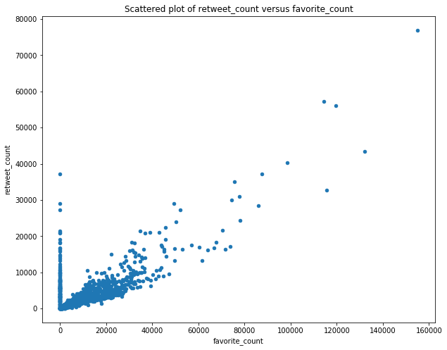

```python
#pd.plotting.scatter_matrix('twitter_archive_clean',figsize =(15,15));
twitter_archive_clean.plot(x='favorite_count', y='retweet_count', kind ='scatter',figsize =(10,8));
plt.title('Scattered plot of retweet_count versus favorite_count')
plt.savefig('twitter_archiveplot.png')
```

```python
image_predictions_clean.info()
```

```
<class 'pandas.core.frame.DataFrame'>
RangeIndex: 2075 entries, 0 to 2074
Data columns (total 12 columns):
tweet_id    2075 non-null object
jpg_url     2075 non-null object
img_num     2075 non-null int64
p1          2075 non-null object
p1_conf     2075 non-null float64
p1_dog      2075 non-null bool
p2          2075 non-null object
p2_conf     2075 non-null float64
p2_dog      2075 non-null bool
p3          2075 non-null object
p3_conf     2075 non-null float64
p3_dog      2075 non-null bool
dtypes: bool(3), float64(3), int64(1), object(5)
memory usage: 152.1+ KB
```

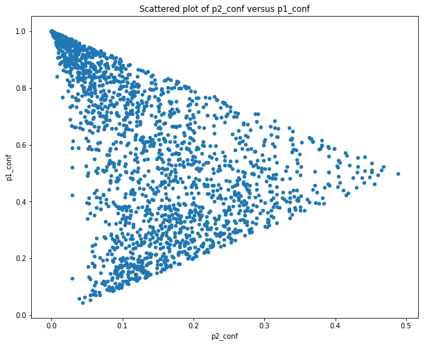

```python
image_predictions.plot(x='p2_conf', y='p1_conf', kind ='scatter',figsize =(10,8));
plt.title('Scattered plot of p2_conf versus p1_conf');
plt.savefig('image_predictionsplot1.png');
```

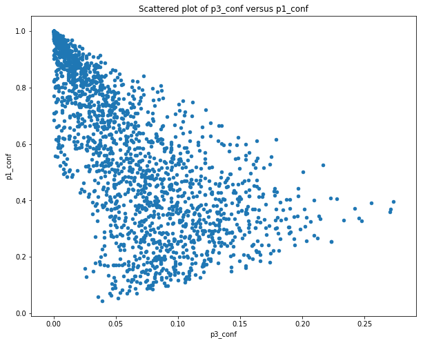

```python
image_predictions.plot(x='p3_conf', y='p1_conf', kind ='scatter',figsize =(10,8));
plt.title('Scattered plot of p3_conf versus p1_conf');
plt.savefig('image_predictionsplot2.png');
```

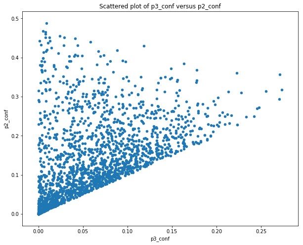

```python
image_predictions.plot(x='p3_conf', y='p2_conf', kind ='scatter',figsize =(10,8));
plt.title('Scattered plot of p3_conf versus p2_conf');
plt.savefig('image_predictionsplot2.png');
```

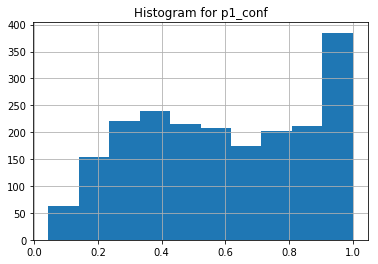

```python
image_predictions.p1_conf.hist();
plt.title('Histogram for p1_conf');
plt.savefig('image_predictionsplot3.png');
```

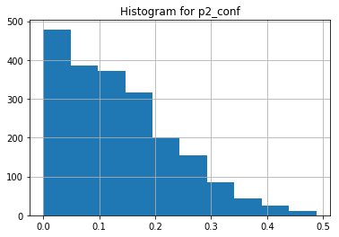

```python
image_predictions.p2_conf.hist();
plt.title('Histogram for p2_conf');
plt.savefig('image_predictionsplot4.png');
```

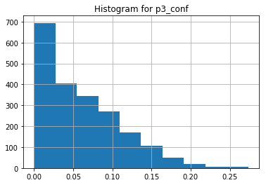

```python
image_predictions.p3_conf.hist();
plt.title('Histogram for p3_conf');
plt.savefig('image_predictionsplot5.png');
```

```python
from subprocess import call
call(['python', '-m', 'nbconvert', 'Wrangle_act.ipynb'])
```

```
255
```